# Lab 3. ANOVA and linear models

Daniel Runcie.

```r
library(ggplot2)
library(emmeans)
library(car)
library(lme4)
library(lmerTest)
library(multcomp)
library(multcompView)
```

## Experiment with more than two treatments

In the following experiment, the nitrogen fixation capacities of six different strains of rhizobia on clover are compared. The experiment is arranged as a completely randomized design (CRD) with 6 treatments (i.e. 5 new strains plus a control) and five independent replications (e.g. plots) per treatment.

**Design**: Completely randomized design

| Structure | Variable | Type | # levels | Experimental Unit |
| --- | --- | --- | --- | --- |
| Treatment | Strain | Categorical | 6 | Plot |
| Design | Plot | Categorical | 30 |  |
| Design | Sample | Categorical | 120 |  |
| Response | NLevel | Numeric | 120 |  |

> Thought Question:

> What types of comparisons among treatments would be most interesting?
- We could compare each new strain to the control.
- Or we could compare all pairs of strains.
- Or we could test the hypothesis that all strains are equivalent.

First, Load the data and check that it was loaded correctly:

```r
clover.dat <- read.csv('~/Desktop/R_Projects/PLS205_Winter2021/PLS205_Winter2021/data/Clover_data.csv')
str(clover.dat)
```

```
'data.frame':   120 obs. of  4 variables:
 $ Sample: int  1 2 3 4 1 2 3 4 1 2 ...
 $ Strain: chr  "3DOk13" "3DOk13" "3DOk13" "3DOk13" ...
 $ Plot  : int  1 1 1 1 2 2 2 2 3 3 ...
 $ NLevel: num  11.6 11.6 12.5 12.4 24.9 25.2 25.1 24.4 14.9 17.5 ...
```

```r
summary(clover.dat)
```

```
     Sample        Strain               Plot          NLevel
 Min.   :1.00   Length:120         Min.   : 1.0   Min.   : 7.30
 1st Qu.:1.75   Class :character   1st Qu.: 8.0   1st Qu.:15.68
 Median :2.50   Mode  :character   Median :15.5   Median :19.45
 Mean   :2.50                      Mean   :15.5   Mean   :19.98
 3rd Qu.:3.25                      3rd Qu.:23.0   3rd Qu.:24.45
 Max.   :4.00                      Max.   :30.0   Max.   :34.60
```

```r
clover.dat$Plot <- as.factor(clover.dat$Plot)
clover.dat$Strain <- as.factor(clover.dat$Strain)
clover.dat$Sample <- as.factor(clover.dat$Sample)
str(clover.dat)
```

```
'data.frame':   120 obs. of  4 variables:
 $ Sample: Factor w/ 4 levels "1","2","3","4": 1 2 3 4 1 2 3 4 1 2 ...
 $ Strain: Factor w/ 6 levels "3DOk1","3DOk13",..: 2 2 2 2 4 4 4 4 6 6 ...
 $ Plot  : Factor w/ 30 levels "1","2","3","4",..: 1 1 1 1 2 2 2 2 3 3 ...
 $ NLevel: num  11.6 11.6 12.5 12.4 24.9 25.2 25.1 24.4 14.9 17.5 ...
```

```r
clover.dat$Plot <- interaction(clover.dat$Strain,clover.dat$Plot)
clover.dat$Plot
```

```
  [1] 3DOk13.1  3DOk13.1  3DOk13.1  3DOk13.1  3DOk5.2   3DOk5.2   3DOk5.2   3DOk5.2   Comp.3    Comp.3    Comp.3    Comp.3    3DOk4.4
 [14] 3DOk4.4   3DOk4.4   3DOk4.4   3DOk4.5   3DOk4.5   3DOk4.5   3DOk4.5   3DOk1.6   3DOk1.6   3DOk1.6   3DOk1.6   3DOk4.7   3DOk4.7
 [27] 3DOk4.7   3DOk4.7   3DOk1.8   3DOk1.8   3DOk1.8   3DOk1.8   3DOk7.9   3DOk7.9   3DOk7.9   3DOk7.9   3DOk13.10 3DOk13.10 3DOk13.10
 [40] 3DOk13.10 3DOk1.11  3DOk1.11  3DOk1.11  3DOk1.11  Comp.12   Comp.12   Comp.12   Comp.12   3DOk4.13  3DOk4.13  3DOk4.13  3DOk4.13
 [53] 3DOk5.14  3DOk5.14  3DOk5.14  3DOk5.14  Comp.15   Comp.15   Comp.15   Comp.15   3DOk5.16  3DOk5.16  3DOk5.16  3DOk5.16  3DOk1.17
 [66] 3DOk1.17  3DOk1.17  3DOk1.17  3DOk4.18  3DOk4.18  3DOk4.18  3DOk4.18  Comp.19   Comp.19   Comp.19   Comp.19   3DOk7.20  3DOk7.20
 [79] 3DOk7.20  3DOk7.20  3DOk13.21 3DOk13.21 3DOk13.21 3DOk13.21 3DOk13.22 3DOk13.22 3DOk13.22 3DOk13.22 3DOk5.23  3DOk5.23  3DOk5.23
 [92] 3DOk5.23  3DOk7.24  3DOk7.24  3DOk7.24  3DOk7.24  3DOk1.25  3DOk1.25  3DOk1.25  3DOk1.25  3DOk13.26 3DOk13.26 3DOk13.26 3DOk13.26
[105] 3DOk5.27  3DOk5.27  3DOk5.27  3DOk5.27  Comp.28   Comp.28   Comp.28   Comp.28   3DOk7.29  3DOk7.29  3DOk7.29  3DOk7.29  3DOk7.30
[118] 3DOk7.30  3DOk7.30  3DOk7.30
180 Levels: 3DOk1.1 3DOk13.1 3DOk4.1 3DOk5.1 3DOk7.1 Comp.1 3DOk1.2 3DOk13.2 3DOk4.2 3DOk5.2 3DOk7.2 Comp.2 3DOk1.3 3DOk13.3 ... Comp.30
```

## Analyzing the data

1. Visualize the data
2. Fit a model to the data
3. Run model diagnostics to check model assumptions
4. Use the model fit to calculate summary statistics and draw conclusions

### Visualize the data

Let’s start by plotting the data to visually inspect

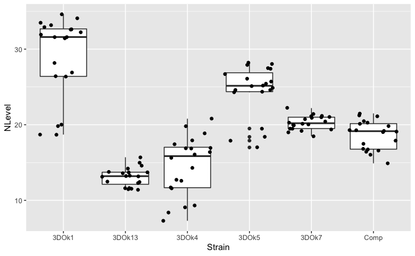

```r
library(ggplot2)
ggplot(clover.dat,aes(x=Strain,y=NLevel)) + geom_boxplot() + geom_jitter()
```

It looks like we do have large differences among the treatments. Let’s see if the statistics backs this up.

### Fit the model:

Since the experimental design of this experiment is also a CRD with only a single class of treatments, the form of the model is the same as for the Barley data.

- The **explanatory** component is the Culture (ie the species of bacteria/ the treatment)
- The **error** component is caused by variation among pots, and measurement error. This is all just variation due to the sampling of experimental units in a CRD, so we don’t write it in our model

Therefore, the model statement looks the same as before:

```r
clover.mod <- lm(NLevel ~ Strain, data = clover.dat)
clover.mod
```

```
Call:
lm(formula = NLevel ~ Strain, data = clover.dat)

Coefficients:
 (Intercept)  Strain3DOk13   Strain3DOk4   Strain3DOk5   Strain3DOk7    StrainComp
      28.865       -15.770       -14.335        -4.425        -8.600       -10.205
```

You’ll notice that we now have more **Coefficients** in the brief model summary.

### Run diagnostic plots

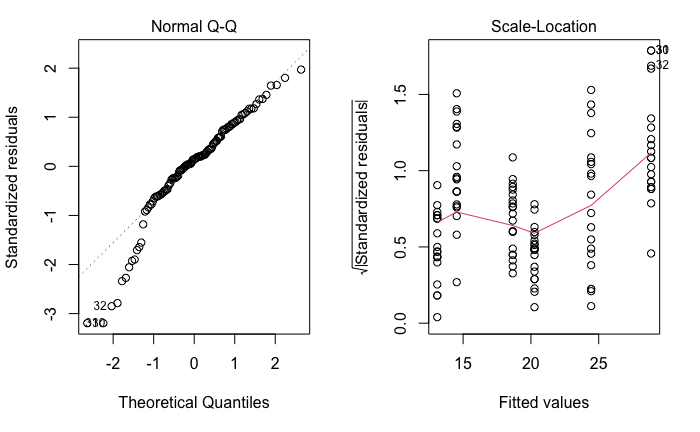

```r
op = par(mfrow=c(1,2))
plot(clover.mod,which = c(2,3))
```

With more complex designs, The **Scale-Location** plot tends to be more useful than the **Residuals vs Factor Levels** plot we used in Lab 2. The **Scale-Location** plot shows the absolute value of standardized residuals against the fitted values. In this case, fitted values are the treatment means (ie the explanatory component of the model). You should check for a trend such as the magnitude of residuals increasing for larger fitted values (a common problem). The red line tries to help visualize this trend.

We do see some problems here. The residuals are a bit skewed (too many small values), and the cultures seem to vary some in their variances, with the cultures with higher Nitrogen levels having slightly higher residuals variances. However, neither looks very severe.

We might want to stop here, or consider data transformations (a later lab). But we’ll continue on for demonstration.

### Generate model summaries and tests

Most of these analyses can be run using the `emmeans` function:

```r
library(emmeans)
```

#### Treatment means

The first analysis might be to simply estimate the mean Nitrogen Level for each of the 6 Cultures.

```r
means_clover = emmeans(clover.mod,~Strain)  # This preps an emmeans analysis, grouping by Culture
summary(means_clover,level = 0.95,infer = c(T,F))  # note setting level (1-alpha) for the confidence intervals
```

```
 Strain emmean   SE  df lower.CL upper.CL
 3DOk1    28.9 0.73 114     27.4     30.3
 3DOk13   13.1 0.73 114     11.6     14.5
 3DOk4    14.5 0.73 114     13.1     16.0
 3DOk5    24.4 0.73 114     23.0     25.9
 3DOk7    20.3 0.73 114     18.8     21.7
 Comp     18.7 0.73 114     17.2     20.1

Confidence level used: 0.95
```

```r
# infer = c(T,F) gives confidence intervals
# infer = c(F,T) gives p-values intervals. Here these are testing against the null hypothesis that mu_i = 0
# infer = c(T,T) gives both.
```

#### Treatment differences

With 6 levels of the treatment, there are several ways of describing differences.

1. We could compare each of the Cultures to a single control treatment
2. We could compare all pairs of Cultures

#### Confidence intervals and hypothesis tests for differences between new cultures and control

We tell `emmeans` to measure the effects of each treatment against the control with the command `trt.vs.ctrl~Culture`, and then specify the control treatment with `ref = 6` because `Comp` is the 6th treatment as listed above. You can see how R orders treatments like this:

```r
levels(clover.dat$Culture)
```

[output not shown]

```r
differences_vs_control = emmeans(clover.mod,trt.vs.ctrl~Strain,ref = 6)  # ref = 6, because the control is the 6th Culture
summary(differences_vs_control,level = 0.95,infer = c(T,T))$contrast
```

```
 contrast      estimate   SE  df lower.CL upper.CL t.ratio p.value
 3DOk1 - Comp     10.21 1.03 114     7.56    12.85  9.885  <.0001
 3DOk13 - Comp    -5.57 1.03 114    -8.21    -2.92 -5.391  <.0001
 3DOk4 - Comp     -4.13 1.03 114    -6.77    -1.49 -4.001  0.0005
 3DOk5 - Comp      5.78 1.03 114     3.14     8.42  5.599  <.0001
 3DOk7 - Comp      1.60 1.03 114    -1.04     4.25  1.555  0.3911

Confidence level used: 0.95
Conf-level adjustment: dunnettx method for 5 estimates
P value adjustment: dunnettx method for 5 tests
```

```r
# by adding $contrast after the summary function, we get only the contrast table, not the treatment means table
```

Note: The summary states that the **dunnetts** method was used to adjust the level of the confidence intervals. This is the correct adjustment for comparisons of treatments against a single control.

This adjustment works by calculating a new **penalty** statistic to replate $t_{\alpha/2,df}$ in the formula for a confidence interval.

The **p.value** for each test is also adjusted so that it is a **simultaneous** p-value for all the tests. It represents the probability that the **biggest** difference among any of the 5 `3DOk` species against the control would be at least as large as the biggest observed difference **if all 5** were the same as the control.